# Análise Exploratória de Dados

Hugo Victor dos Santos Silva

22 de abril de 2023

# Projeto Final De Análise Exploratória de Dados

**Professor:** Otto Tavares

**Alunos:** Hugo Silva

#### Este trabalho têm como objetivo tentar identificar se há relação entre educ e dem_ind. A hipótese é que quanto maior a educ maior será o dem_ind.

1. Utilizando o pacote summarytools (função descr), descreva estatisticamente a sua base de dados.

```r
descr(df_democracy)
```

```
## Descriptive Statistics
## df_democracy
## N: 9
##
##                     age_median   dem_ind    educ   log_pop
## ----------------- ------------ --------- ------- ---------
##              Mean        22.63      0.64    5.93      9.27
##           Std.Dev         2.42      0.41    0.97      0.21
##               Min        20.30      0.00    4.77      8.94
##                Q1        20.80      0.17    5.24      9.11
##            Median        21.70      0.83    5.75      9.28
##                Q3        24.10      0.97    6.59      9.44
##               Max        27.00      1.00    7.53      9.56
##               MAD         1.93      0.25    0.78      0.24
##               IQR         3.30      0.80    0.95      0.28
##                CV         0.11      0.63    0.16      0.02
##          Skewness         0.62     -0.56    0.45     -0.14
##       SE.Skewness         0.72      0.72    0.75      0.75
##          Kurtosis        -1.32     -1.71   -1.41     -1.54
##           N.Valid         9.00      9.00    8.00      8.00
##         Pct.Valid       100.00    100.00   88.89     88.89
```

4. Crie um gráfico com a matriz de espalhamento (scatter matrix plot) para sua base de dados.Através de investigação visual, quais são as variáveis mais correlacionadas. Apresente o gráfico e justifique.

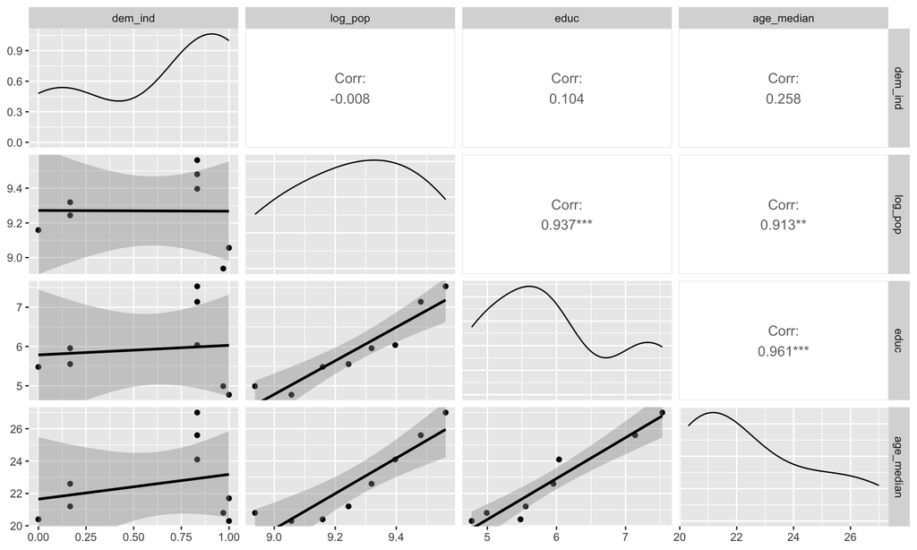

```r
ggpairs(data = df_democracy, lower = list(continuous = "smooth"))
```

R= As variáveis de maior correlação são: - age_median X educ - educ X log_pop - age_median X log_pop Essas relações fortes ficam bem claras pela distribuição linear descrita nos gráficos de relação.

     ````
       ```
       bins_dem_ind = (3.5 * sd(df_democracy$dem_ind)) / (nrow(df_democracy[, "dem_ind"]) ^ (1/3))
       ggplot(df_democracy, aes(x = dem_ind)) +
           geom_histogram(bins=bins_dem_ind)
       ```
     ````

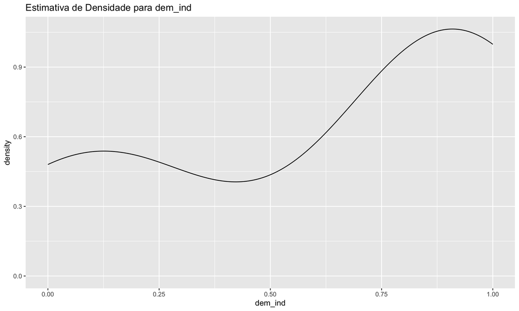

       ```r
           ggplot(df_democracy, aes(x = dem_ind)) +
               geom_density() +
               labs(title = "Estimativa de Densidade para dem_ind")
       ```

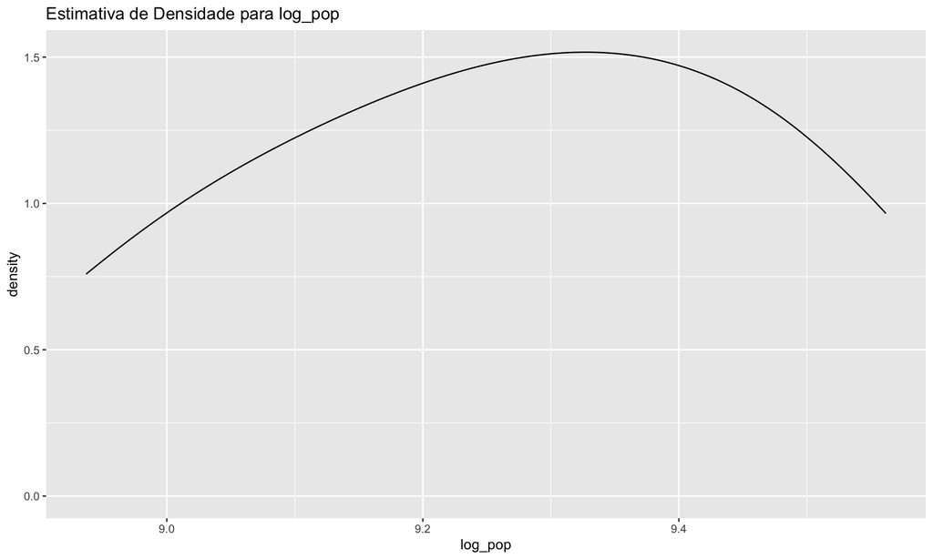

       ```r
           ggplot(df_democracy, aes(x = log_pop)) +
               geom_density() +
               labs(title = "Estimativa de Densidade para log_pop")
       ```

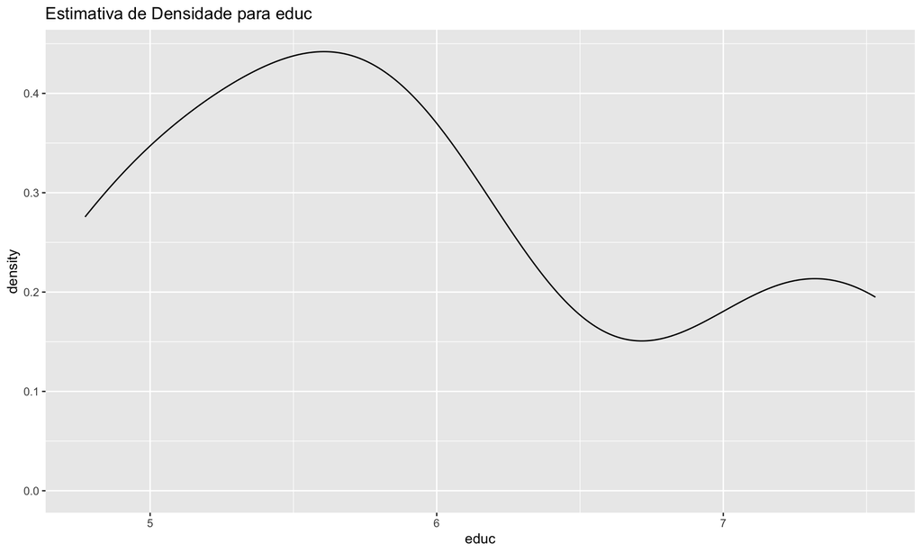

       ```r
           ggplot(df_democracy, aes(x = educ)) +
               geom_density() +
               labs(title = "Estimativa de Densidade para educ")
       ```

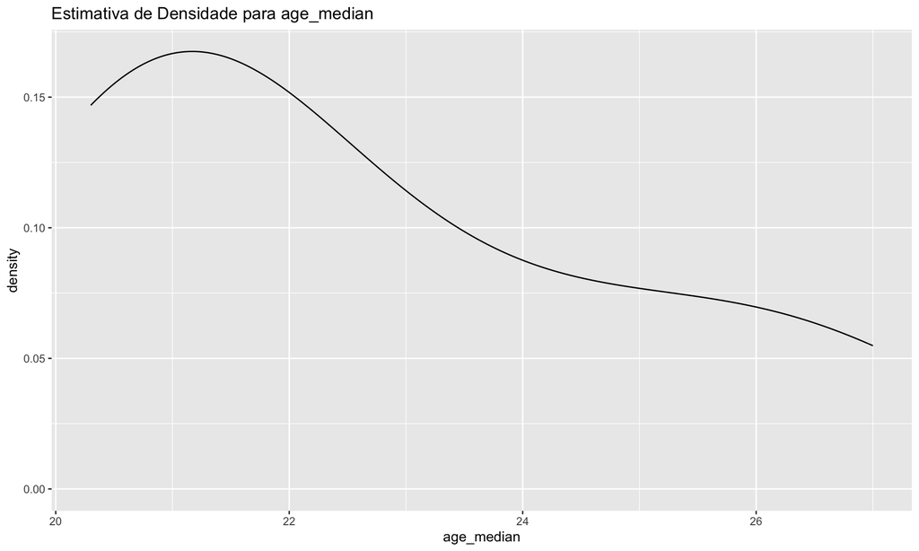

       ```r
           ggplot(df_democracy, aes(x = age_median)) +
               geom_density() +
               labs(title = "Estimativa de Densidade para age_median")
       ```

   3. Crie um gráfico Q-Q para cada variável de sua base de dados. (use as funções presentes no pacote ggpubr)

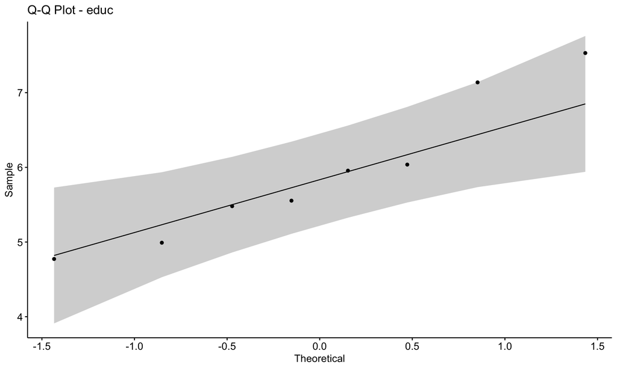

      ```r
      # criação dos gráficos Q-Q
      ggqqplot(df_democracy$educ) + ggtitle("Q-Q Plot - educ")
      ```

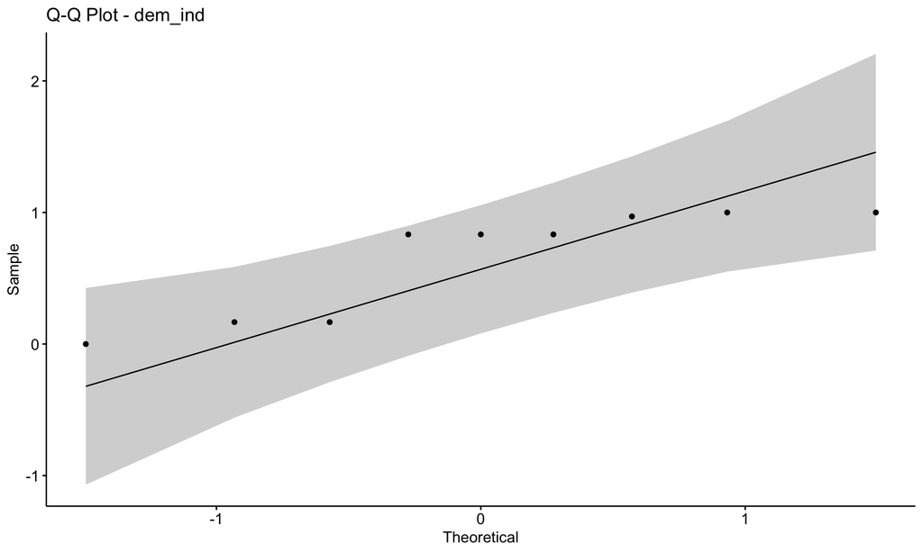

      ```r
      ggqqplot(df_democracy$dem_ind) + ggtitle("Q-Q Plot - dem_ind")
      ```

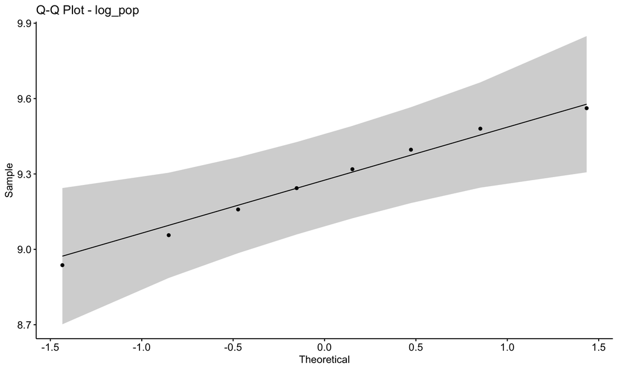

      ```r
      ggqqplot(df_democracy$log_pop) + ggtitle("Q-Q Plot - log_pop")
      ```

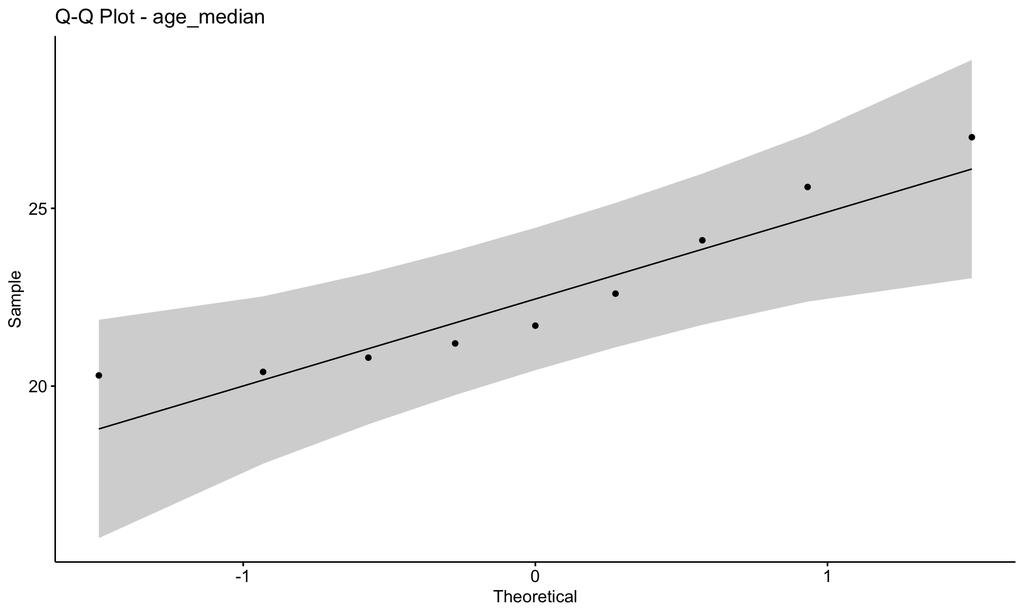

      ```r
      ggqqplot(df_democracy$age_median) + ggtitle("Q-Q Plot - age_median")
      ```

   4. Execute um teste de normalidade Shapiro-Wilk

      ```r
      # Separa valores para executar teste de Shapiro
      df_democracy_shapiro_dem_ind <- shapiro.test(df_democracy$dem_ind)
      df_democracy_shapiro_log_pop <- shapiro.test(df_democracy$log_pop)
      df_democracy_shapiro_educ <- shapiro.test(df_democracy$educ)
      df_democracy_shapiro_age_median <- shapiro.test(df_democracy$age_median)


      df_shapiro <- data.frame(
      Variavel = c("dem_ind", "log_pop", "educ", "age_median"),
      Estatistica = c(df_democracy_shapiro_dem_ind$statistic,
                      df_democracy_shapiro_log_pop$statistic,
                      df_democracy_shapiro_educ$statistic,
                      df_democracy_shapiro_age_median$statistic),
      p_valor = c(df_democracy_shapiro_dem_ind$p.value,
                  df_democracy_shapiro_log_pop$p.value,
                  df_democracy_shapiro_educ$p.value,
                  df_democracy_shapiro_age_median$p.value)
      )

      kable(df_shapiro, "html", caption="Teste de Normalidade de Shapiro-Wilk para Dados do Chile") %>%
          kable_styling("striped")
      ```

      Teste de Normalidade de Shapiro-Wilk para Dados do Chile

      | Variavel | Estatistica | p_valor |
      | --- | --- | --- |
      | dem_ind | 0.7748310 | 0.0105015 |
      | log_pop | 0.9811060 | 0.9681693 |
      | educ | 0.9231292 | 0.4557652 |
      | age_median | 0.8811132 | 0.1613068 |

   5. Baseado nos itens anteriores, é possível afirmar que algumas das variáveis se aproximam de uma distribuição normal? Justifique.

      R= Sim, a variável `log_pop` pois com base no Q-Q plot e no gráfico de densidade apresentados, podemos observar que os dados parecem seguir uma distribuição normal, pois a linha do Q-Q plot está muito próxima da diagonal e a distribuição no gráfico de densidade é simétrica e com aparência de sino. O p-valor do teste Shapiro-Wilk também confirma essa suspeita, pois um p-valor de 0.9681693 indica que não há evidências suficientes para rejeitar a hipótese nula de que os dados foram amostrados de uma distribuição normal. Portanto, podemos concluir que os dados parecem seguir uma distribuição normal com alta probabilidade.
6. Qualidade de dados tem sido um dos temas mais abordados nos projetos de estruturação em data analytics, sendo um dos principais indicadores do nível de maturidade das organizações. Um dos problemas mais comuns de qualidade é relacionado à completude de dados. Em suas palavras, como é definido completude? Qual o impacto em uma análise exploratória de dados?

   R=O ato de garantir que as informações em um conjunto de dados estejam completas é de grande importância na análise de dados. A completude é a medida em que as informações necessárias estão presentes em um conjunto de dados. Quando informações importantes estão ausentes, os resultados da análise exploratória de dados podem ser afetados. Portanto, é crucial garantir que os dados estejam completos e prontos para a análise. A qualidade dos dados é um aspecto crítico em projetos de ciência de dados e é um dos principais indicadores de maturidade organizacional. É importante lembrar que a completude dos dados deve ser tratada de forma adequada para evitar resultados imprecisos ou conclusões errôneas.
7. Qual a completude para cada uma das variáveis do seu banco de dados?

   ```r
   1 - colMeans(is.na(df_democracy))
   ```

   ```
   ##    dem_ind    log_pop       educ age_median
   ##  1.0000000  0.8888889  0.8888889  1.0000000
   ```

8. Realize uma operação de imputação de dados usando o pacote MICE.

```
# Cria a matrix de correlação
cor_matrix <- cor(df_democracy)

# Substitui NA por 0 na matriz
cor_matrix[is.na(cor_matrix)] <- 0

# Faz a substituição dos dados vazios utilizando as fortes correlações em uma regressão linear
mice_obj <- mice(df_democracy, method="pmm", predictorMatrix=cor_matrix, seed=456)
imputed_data <- complete(mice_obj)
```

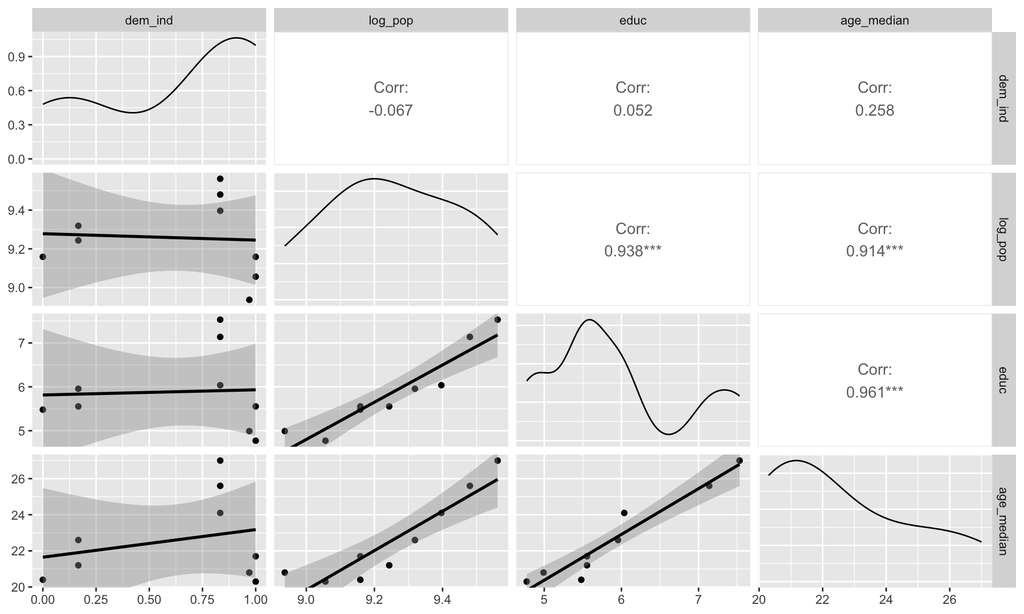

```r
ggpairs(data = imputed_data, lower = list(continuous = "smooth"))
```

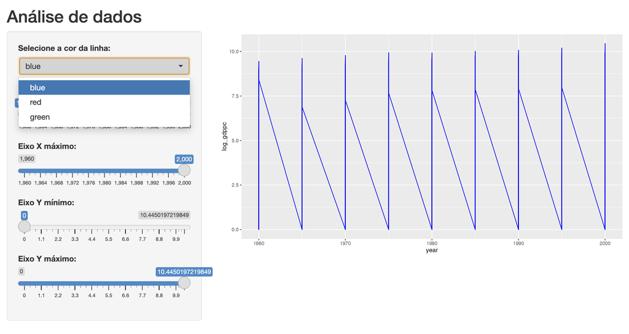

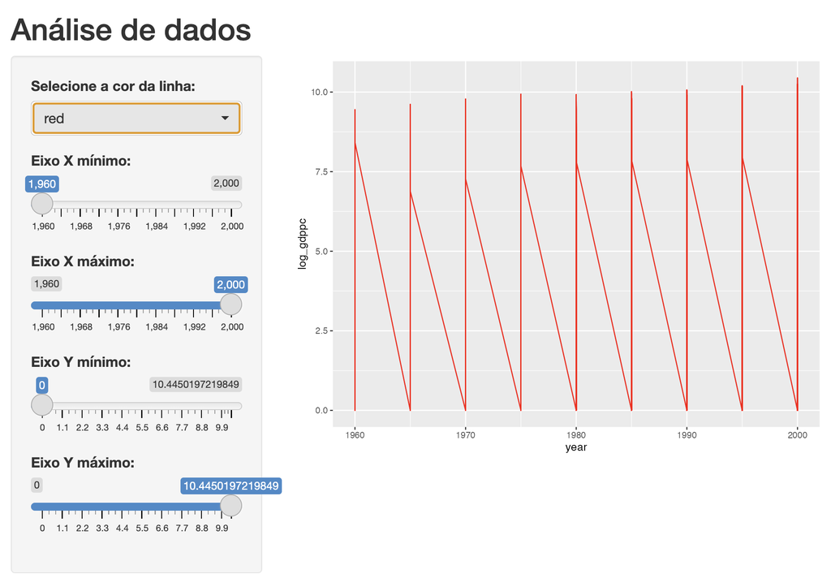

10. Disponibilize os códigos (RMarkdown e Shiny) em uma plataforma de compartilhamento de códigos (sugestão GitHub)
    - Todos os códigos desse projeto podem ser acessado no [GitHub](https://github.com/hugoadriao/estatistica_dados_faltantes_projeto_final)
    - Este projeto rmd pode ser visualizado em [GitHub Pages](https://hugoadriao.github.io/estatistica_dados_faltantes_projeto_final/)